# Modern Data Mining - HW 5

Joshua Benadiva

Christine O’Hara

Mintai Bautista

Due: 11:59Pm, 4/16, 2023

# Problem 2: IQ and successes

## Background: Measurement of Intelligence

Case Study: how intelligence relates to one’s future successes?

ASVAB (Armed Services Vocational Aptitude Battery) tests have been used as a screening test for those who want to join the army or other jobs.

Our data set IQ.csv is a subset of individuals from the 1979 National Longitudinal Study of Youth (NLSY79) survey who were re-interviewed in 2006. Information about family, personal demographic such as gender, race and education level, plus a set of ASVAB (Armed Services Vocational Aptitude Battery) test scores are available. It is STILL used as a screening test for those who want to join the army! ASVAB scores were 1981 and income was 2005.

**Our goals:**

- Is IQ related to one’s successes measured by Income?
- Is there evidence to show that Females are under-paid?
- What are the best possible prediction models to predict future income?

**The ASVAB has the following components:**

- Science, Arith (Arithmetic reasoning), Word (Word knowledge), Parag (Paragraph comprehension), Numer (Numerical operation), Coding (Coding speed), Auto (Automative and Shop information), Math (Math knowledge), Mechanic (Mechanic Comprehension) and Elec (Electronic information).
- AFQT (Armed Forces Qualifying Test) is a combination of Word, Parag, Math and Arith.
- Note: Service Branch requirement: Army 31, Navy 35, Marines 31, Air Force 36, and Coast Guard 45,(out of 100 which is the max!)

**The detailed variable definitions:**

Personal Demographic Variables:

- Race: 1 = Hispanic, 2 = Black, 3 = Not Hispanic or Black
- Gender: a factor with levels “female” and “male”
- Educ: years of education completed by 2006

Household Environment:

- Imagazine: a variable taking on the value 1 if anyone in the respondent’s household regularly read magazines in 1979, otherwise 0
- Inewspaper: a variable taking on the value 1 if anyone in the respondent’s household regularly read newspapers in 1979, otherwise 0
- Ilibrary: a variable taking on the value 1 if anyone in the respondent’s household had a library card in 1979, otherwise 0
- MotherEd: mother’s years of education
- FatherEd: father’s years of education

Variables Related to ASVAB test Scores in 1981 (Proxy of IQ’s)

- AFQT: percentile score on the AFQT intelligence test in 1981
- Coding: score on the Coding Speed test in 1981
- Auto: score on the Automotive and Shop test in 1981
- Mechanic: score on the Mechanic test in 1981
- Elec: score on the Electronics Information test in 1981
- Science: score on the General Science test in 1981
- Math: score on the Math test in 1981
- Arith: score on the Arithmetic Reasoning test in 1981
- Word: score on the Word Knowledge Test in 1981
- Parag: score on the Paragraph Comprehension test in 1981
- Numer: score on the Numerical Operations test in 1981

Variable Related to Life Success in 2006

- Income2005: total annual income from wages and salary in 2005. We will use a natural log transformation over the income.

**Note: All the Esteem scores shouldn’t be used as predictors to predict income**

## 1. EDA: Some cleaning work is needed to organize the data.

```r
iq_data <- fread("IQ.Full.csv")
print(iq_data)
```

```
##       Subject Imagazine Inewspaper Ilibrary MotherEd FatherEd FamilyIncome78
##    1:       2         1          1        1        5        8          20000
##    2:       6         0          1        1       12       12          35000
##    3:       7         1          1        1       12       12           8502
##    4:       8         1          1        1        9        6           7227
##    5:       9         1          1        1       12       10          17000
##   ---
## 2580:   12133         0          1        1       10        3           1500
## 2581:   12135         0          1        0       10       10            572
## 2582:   12138         1          1        1        9       15          13000
## 2583:   12139         1          1        1        8        9          13000
## 2584:   12140         0          1        1        9        5          12410
##       Race Gender Educ Science Arith Word Parag Numer Coding Auto Math Mechanic
##    1:    3 female   12       6     8   15     6    29     52    9    6       10
##    2:    3   male   16      23    30   35    15    45     68   21   23       21
```

[output cut: 33 more lines]

- The first variable is the label for each person. Take that out.
- Set categorical variables as factors.
- Make log transformation for Income and take the original Income out
- Take the last person out of the dataset and label it as **Michelle**.
- When needed, split data to three portions: training, testing and validation (70%/20%/10%)
  - training data: get a fit
  - testing data: find the best tuning parameters/best models
  - validation data: only used in your final model to report the accuracy.

```r
iq_data <- iq_data[, -1]
iq_data$Race <- as.factor(iq_data$Race)
iq_data$Gender <- as.factor(iq_data$Gender)
iq_data$LogIncome2005 <- log(iq_data$Income2005)
iq_data <- subset(iq_data, select = -Income2005)
michelle <- iq_data[nrow(iq_data), ]
iq_data <- iq_data[-nrow(iq_data), ]
set.seed(123) # Set a seed for reproducibility
total_rows <- nrow(iq_data)
train_rows <- floor(total_rows * 0.7)
test_rows <- floor(total_rows * 0.2)

# Shuffle data
shuffled_data <- iq_data[sample(nrow(iq_data)), ]

# Split data
train_data <- shuffled_data[1:train_rows, ]
test_data <- shuffled_data[(train_rows + 1):(train_rows + test_rows), ]
validation_data <- shuffled_data[(train_rows + test_rows + 1):total_rows, ]
```

## 2. Factors affect Income

We only use linear models to answer the questions below.

1. To summarize ASVAB test scores, create PC1 and PC2 of 10 scores of ASVAB tests and label them as ASVAB_PC1 and ASVAB_PC2. Give a quick interpretation of each ASVAB_PC1 and ASVAB_PC2 in terms of the original 10 tests.

```r
# Extract ASVAB test scores
asvab_scores <- iq_data[, c("Science", "Arith", "Word", "Parag", "Numer", "Coding", "Auto", "Math", "Mechanic", "Elec")]

# Perform PCA
asvab_pca <- prcomp(asvab_scores, scale = TRUE)

# Add PC1 and PC2 to the dataset
iq_data$ASVAB_PC1 <- asvab_pca$x[, 1]
iq_data$ASVAB_PC2 <- asvab_pca$x[, 2]
asvab_pca$rotation[, 1:2]
```

```
##                PC1         PC2
## Science  0.3518528 -0.14181863
## Arith    0.3543093  0.04873546
## Word     0.3496059  0.06147760
## Parag    0.3262639  0.18966524
## Numer    0.2748967  0.45177204
## Coding   0.2338653  0.51465945
## Auto     0.2722293 -0.47336402
## Math     0.3359736  0.14256444
## Mechanic 0.3160660 -0.33469628
## Elec     0.3237995 -0.33521321
```

Based on the PCA results for the ASVAB test scores, PC1 and PC2 capture different aspects of the test scores.

PC1: PC1 has positive loadings for all 10 tests, which suggests that it represents a general aptitude or overall ability level. This means that individuals who score high on PC1 tend to perform well across all tests, while those who score low on PC1 perform poorly across all tests. A high value of ASVAB_PC1 indicates strong performance in all areas, reflecting a more versatile skill set.

PC2: PC2, on the other hand, shows a mix of positive and negative loadings. The tests with positive loadings are Arith, Word, Parag, Numer, Coding, and Math. The tests with negative loadings are Science, Auto, Mechanic, and Elec. PC2 seems to capture the contrast between verbal/numerical skills (positive loadings) and technical/mechanical skills (negative loadings). A high value of ASVAB_PC2 indicates a stronger performance in verbal and numerical skills and a weaker performance in technical and mechanical skills, whereas a low value indicates the opposite.

2. Is there any evidence showing ASVAB test scores in terms of ASVAB_PC1 and ASVAB_PC2, might affect the Income? Show your work here. You may control a few other variables, including gender.

```r
income_model <- lm(LogIncome2005 ~ ASVAB_PC1 + ASVAB_PC2 + Gender, data = iq_data)
summary(income_model)
```

```
##
## Call:
## lm(formula = LogIncome2005 ~ ASVAB_PC1 + ASVAB_PC2 + Gender,
##     data = iq_data)
##
## Residuals:
##     Min      1Q  Median      3Q     Max
## -6.7273 -0.3462  0.1245  0.5244  2.6121
##
## Coefficients:
##              Estimate Std. Error t value Pr(>|t|)
## (Intercept) 10.098144   0.028181 358.336  < 2e-16 ***
## ASVAB_PC1    0.109464   0.007123  15.367  < 2e-16 ***
## ASVAB_PC2    0.094176   0.018239   5.163 2.61e-07 ***
## Gendermale   0.671353   0.044107  15.221  < 2e-16 ***
## ---
## Signif. codes:  0 '***' 0.001 '**' 0.01 '*' 0.05 '.' 0.1 ' ' 1
##
## Residual standard error: 0.8756 on 2579 degrees of freedom
## Multiple R-squared:  0.1928, Adjusted R-squared:  0.1919
## F-statistic: 205.4 on 3 and 2579 DF,  p-value: < 2.2e-16
```

ASVAB_PC1: The coefficient for ASVAB_PC1 is 0.109464, with a highly significant p-value (< 2e-16). This indicates that there is a positive relationship between the first principal component of ASVAB test scores (general aptitude) and income. As an individual’s general aptitude (ASVAB_PC1) increases, their income also tends to increase.

ASVAB_PC2: The coefficient for ASVAB_PC2 is 0.094176, with a significant p-value (2.61e-07). This suggests a positive relationship between the second principal component of ASVAB test scores (verbal and numerical skills vs. technical and mechanical skills) and income. As an individual’s verbal and numerical skills relative to their technical and mechanical skills (ASVAB_PC2) increase, their income also tends to increase.

Gender: The coefficient for Gendermale is 0.671353, with a highly significant p-value (< 2e-16). This indicates that, on average, male individuals tend to have higher incomes than female individuals.

The model has an adjusted R-squared of 0.1919, which implies that about 19.19% of the variation in income can be explained by the ASVAB_PC1, ASVAB_PC2, and gender variables. While this is not a very high value, it does suggest a significant relationship between ASVAB test scores, gender, and income.

3. Is there any evidence to show that there is gender bias against either male or female in terms of income in the above model?

Yes, there is evidence of gender bias in terms of income in the given model. The coefficient for Gendermale is 0.671353, with a highly significant p-value (< 2e-16). This result suggests that, on average, male individuals tend to have higher incomes than female individuals, even when controlling for ASVAB_PC1 and ASVAB_PC2 scores.

We next build a few models for the purpose of prediction using all the information available. From now on you may use the three data sets setting (training/testing/validation) when it is appropriate.

## 3. Trees

1. fit1: tree(Income ~ Educ + Gender, data.train) with default set up

```r
library(tree)

fit1 <- tree(LogIncome2005 ~ Educ + Gender, data = train_data)
```

```
a) Display the tree
```

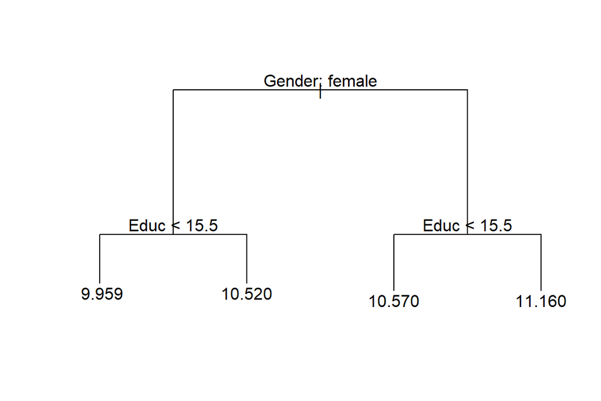

```
b) How many end nodes? Briefly explain how the estimation is obtained in each end nodes and deescribe the prediction equation
```

```r
plot(fit1)
text(fit1, pretty = 0)
```

```r
length(unique(fit1$where))
```

```
## [1] 4
```

The estimation in each end node is obtained by calculating the average LogIncome2005 for all observations within that node. When making predictions using this decision tree, the input observation will traverse the tree following the binary splits until it reaches an end node. The predicted value for that observation will be the average LogIncome2005 of the samples within the end node.

The prediction equation is not a single equation like in linear regression. Instead, it is a set of rules or binary decisions based on the input features (Educ and Gender) that guide the observation through the tree structure until it reaches an end node, where the average LogIncome2005 of that node is used as the predicted value. For the left branch (Female):

The split after gender is based on Educ < 15.5: Left end node (terminal node): Educ < 15.5, predicted LogIncome2005 = 9.959 Right end node (terminal node): Educ >= 15.5, predicted LogIncome2005 = 10.520 For the right branch (Male):

The split after gender is based on Educ < 15.5: Left end node (terminal node): Educ < 15.5, predicted LogIncome2005 = 10.570 Right end node (terminal node): Educ >= 15.5, predicted LogIncome2005 = 11.160

```
c) Does it show interaction effect of Gender and Educ over Income?
```

```
d) Predict Michelle's income
```

```r
michelle_pred <- predict(fit1, newdata = michelle)
exp(michelle_pred)  # Convert back to original income scale
```

```
##        1
## 21148.45
```

2. fit2: fit2 <- rpart(Income2005 ~., data.train, minsplit=20, cp=.009)

```r
fit2 <- rpart(LogIncome2005 ~ ., data = train_data, minsplit = 20, cp = 0.009)
```

```
a) Display the tree using plot(as.party(fit2), main="Final Tree with Rpart")
```

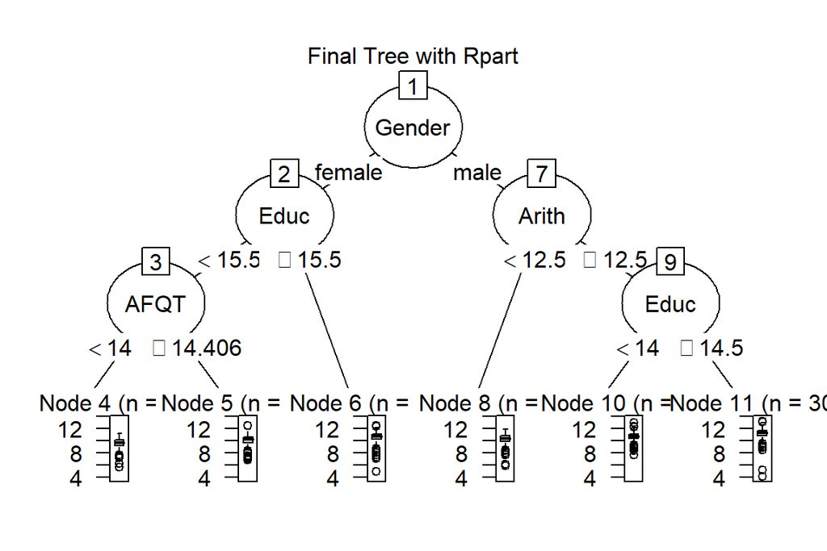

```
b) A brief summary of the fit2
```

```r
plot(as.party(fit2), main = "Final Tree with Rpart")
```

```r
summary(fit2)
```

```
## Call:
## rpart(formula = LogIncome2005 ~ ., data = train_data, minsplit = 20,
##     cp = 0.009)
##   n= 1808
##
##           CP nsplit rel error    xerror       xstd
## 1 0.10726125      0 1.0000000 1.0014578 0.05753946
## 2 0.04483365      1 0.8927387 0.8945592 0.05554672
## 3 0.03611548      2 0.8479051 0.8595404 0.05498685
## 4 0.02098962      3 0.8117896 0.8350812 0.05501844
## 5 0.01659294      4 0.7908000 0.8212111 0.05667287
## 6 0.00900000      5 0.7742071 0.7974194 0.05574157
##
## Variable importance
##   Gender    Arith     AFQT     Educ     Auto     Math     Elec Mechanic
##       18       10       10        9        9        7        7        7
##  Science     Word    Parag   Coding FatherEd    Numer
##        6        6        4        4        2        1
##
## Node number 1: 1808 observations,    complexity param=0.1072613
##   mean=10.4394, MSE=0.9125225
##   left son=2 (903 obs) right son=3 (905 obs)
##   Primary splits:
##       Gender splits as  LR,          improve=0.10726130, (0 missing)
##       Auto   < 14.5    to the left,  improve=0.08363814, (0 missing)
##       Educ   < 15.5    to the left,  improve=0.07996034, (0 missing)
##       Arith  < 16.5    to the left,  improve=0.07515886, (0 missing)
##       Elec   < 12.5    to the left,  improve=0.07482886, (0 missing)
##   Surrogate splits:
##       Auto     < 14.5    to the left,  agree=0.765, adj=0.529, (0 split)
##       Elec     < 13.5    to the left,  agree=0.692, adj=0.384, (0 split)
##       Mechanic < 16.5    to the left,  agree=0.687, adj=0.373, (0 split)
##       Coding   < 47.5    to the right, agree=0.608, adj=0.215, (0 split)
##       Science  < 17.5    to the left,  agree=0.592, adj=0.184, (0 split)
##
## Node number 2: 903 observations,    complexity param=0.03611548
##   mean=10.1262, MSE=0.9103818
##   left son=4 (635 obs) right son=5 (268 obs)
##   Primary splits:
##       Educ  < 15.5    to the left,  improve=0.07248099, (0 missing)
```

[output cut: 61 more lines]

```
##       FatherEd < 14.5    to the left,  agree=0.695, adj=0.295, (0 split)
##       Word     < 30.5    to the left,  agree=0.684, adj=0.269, (0 split)
##       Arith    < 26.5    to the left,  agree=0.682, adj=0.266, (0 split)
##
## Node number 8: 89 observations
##   mean=9.445045, MSE=0.9399741
##
## Node number 9: 546 observations
##   mean=10.04315, MSE=0.7413457
##
## Node number 14: 400 observations
##   mean=10.71065, MSE=0.3861599
##
## Node number 15: 305 observations
##   mean=11.15799, MSE=0.7598676
```

```
c) Compare testing errors between fit1 and fit2. Is the training error from fit2 always less than that from fit1? Is the testing error from fit2 always smaller than that from fit1?
```

```r
# Predictions for fit1 and fit2
pred_fit1 <- predict(fit1, newdata = test_data)
pred_fit2 <- predict(fit2, newdata = test_data)

# Calculate the Mean Squared Error (MSE) for both models
mse_fit1 <- mean((test_data$LogIncome2005 - pred_fit1)^2)
mse_fit2 <- mean((test_data$LogIncome2005 - pred_fit2)^2)

# Display the MSE for both models
cat("MSE for fit1:", mse_fit1, "\n")
```

```
## MSE for fit1: 0.9128741
```

```r
cat("MSE for fit2:", mse_fit2, "\n")
```

```
## MSE for fit2: 0.8698111
```

Is the training error from fit2 always less than that from fit1? It’s not guaranteed that the training error from fit2 will always be less than that from fit1. It depends on the complexity of the models and the specific data we’re working with. In general, a more complex model may have a smaller training error, but it could also be more prone to overfitting.

Is the testing error from fit2 always smaller than that from fit1? Again, there’s no guarantee that the testing error for fit2 will always be smaller than that for fit1. It depends on how well each model generalizes to unseen data. A model with better generalization will have a smaller testing error.

Based on the results, the testing error for fit2 is smaller than that for fit1. This indicates that fit2 generalizes better to the unseen data in our test dataset than fit1. In this specific case, using fit2 (the model created with rpart) would likely provide better predictions for new data compared to fit1 (the model created with the tree package).

` d) You may prune the fit2 to get a tree with small testing error.

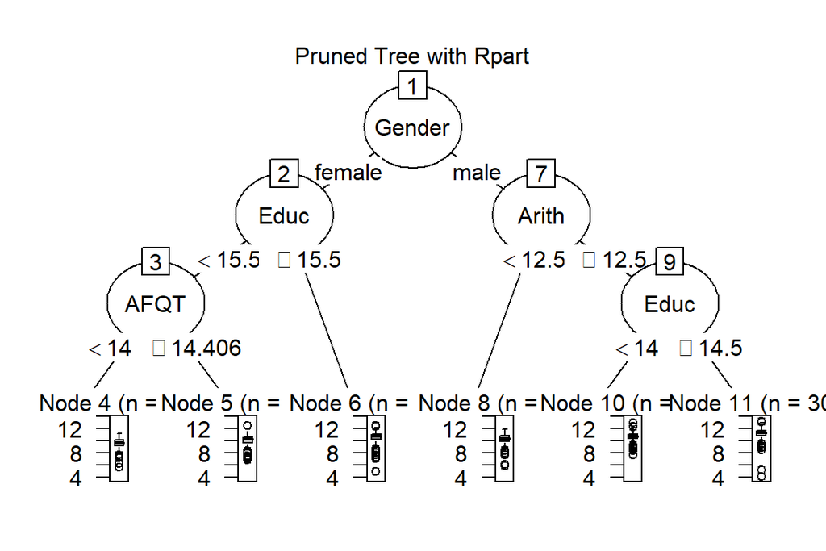

```r
library(rpart)
control_params <- rpart.control(minsplit = 20, cp = 0.009, xval = 10)  # 10-fold cross-validation

fit2_cv <- rpart(LogIncome2005 ~ ., data = train_data, control = control_params)
optimal_cp <- fit2_cv$cptable[which.min(fit2_cv$cptable[, "xerror"]), "CP"]
pruned_fit2 <- prune(fit2, cp = optimal_cp)
plot(as.party(pruned_fit2), main = "Pruned Tree with Rpart")
```

3. fit3: bag two trees

```
a) Take 2 bootstrap training samples and build two trees using the
rpart(Income2005 ~., data.train.b, minsplit=20, cp=.009). Display both trees.
```

[figure not shown]

```r
set.seed(123)  # Set a seed for reproducibility

# Create two bootstrap samples of the training data
train_data_b1 <- train_data[sample(nrow(train_data), replace = TRUE), ]
train_data_b2 <- train_data[sample(nrow(train_data), replace = TRUE), ]
fit3_tree1 <- rpart(LogIncome2005 ~ ., data = train_data_b1, minsplit = 20, cp = 0.009)
fit3_tree2 <- rpart(LogIncome2005 ~ ., data = train_data_b2, minsplit = 20, cp = 0.009)

plot(as.party(fit3_tree1), main = "Bootstrap Tree 1 with Rpart")
```

[figure not shown]

```r
plot(as.party(fit3_tree2), main = "Bootstrap Tree 2 with Rpart")
```

b) Explain how to get fitted values for Michelle by bagging the two trees obtained above. Do not use the predict(). Traverse the first tree (fit3_tree1) using Michelle’s data and find the terminal node where her data point falls. This can be done by following the splits based on the values of her predictor variables.

Retrieve the mean LogIncome2005 value for the terminal node in the first tree where Michelle’s data point falls.

Repeat steps 1 and 2 for the second tree (fit3_tree2).

Average the mean LogIncome2005 values from both trees’ terminal nodes to obtain the final prediction for Michelle’s LogIncome2005.

To get Michelle’s predicted income, take the exponent of the final LogIncome2005 prediction to convert it back to the original income scale.

```
c) What is the testing error for the bagged tree. Is it guaranteed that the testing error by bagging the two tree always smaller that either single tree?
```

```r
pred_tree1 <- predict(fit3_tree1, newdata = test_data)
pred_tree2 <- predict(fit3_tree2, newdata = test_data)

# Average predictions to obtain bagged predictions
bagged_pred <- (pred_tree1 + pred_tree2) / 2

# Calculate the mean squared error
mse_bagged <- mean((test_data$LogIncome2005 - bagged_pred)^2)
print(mse_bagged)
```

```
## [1] 0.9197443
```

No, it’s not guaranteed that the testing error for the bagged trees will always be smaller than the error from either single tree. However, bagging can help improve model stability and reduce overfitting by averaging the predictions from multiple trees. This can often lead to better generalization and a lower testing error. The effectiveness of bagging depends on the specific problem, the dataset, and the underlying decision trees.

4. fit4: Build a best possible RandomForest
   1. Show the process how you tune mtry and number of trees. Give a very high level explanation how fit4 is built.

```r
set.seed(555)
fit4 <- randomForest(LogIncome2005 ~ ., data = train_data, mtry = 5, ntree = 500)
names(fit4)
```

```
##  [1] "call"            "type"            "predicted"       "mse"
##  [5] "rsq"             "oob.times"       "importance"      "importanceSD"
##  [9] "localImportance" "proximity"       "ntree"           "mtry"
## [13] "forest"          "coefs"           "y"               "test"
## [17] "inbag"           "terms"
```

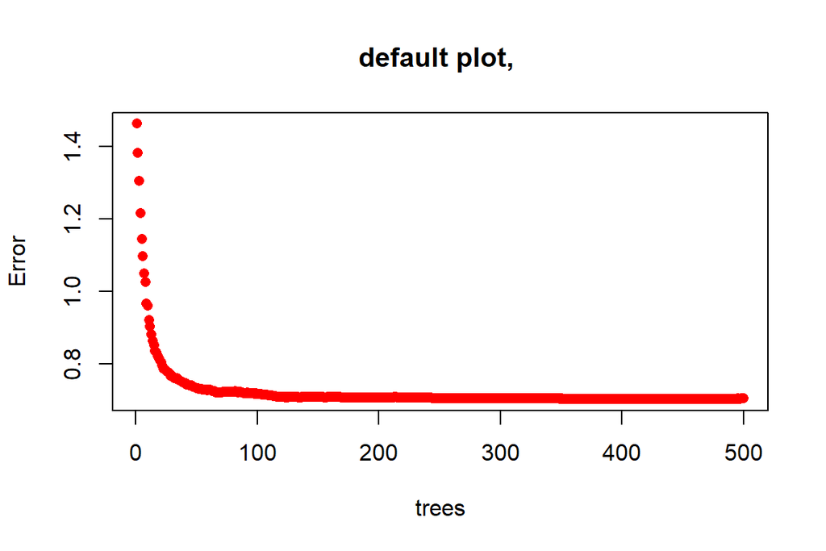

```r
plot(fit4, col="red", pch=16, type="p",
     main="default plot, ")
```

Before we can explain all the output. We first get the predicted values and training error.

```r
# Obtain predicted values for the training set
train_pred <- predict(fit4, newdata = train_data)

# Calculate the mean squared error for the training set
mse_train <- mean((train_data$LogIncome2005 - train_pred)^2)

# Print the mean squared error
print(mse_train)
```

```
## [1] 0.1512508
```

Now to see th oob.times and store the predicted values under the predicted oob, and store the mean squared error.

```r
head(fit4$oob.times) # how many times each obs'n belong to OOB. We expect to see 1/e=1/3 (.37)
```

```
## [1] 188 163 182 189 183 183
```

```r
predicted_oob <- fit4$predicted   # OOB predicted values
mse_oob <- mean((train_data$LogIncome2005 - predicted_oob)^2)
```

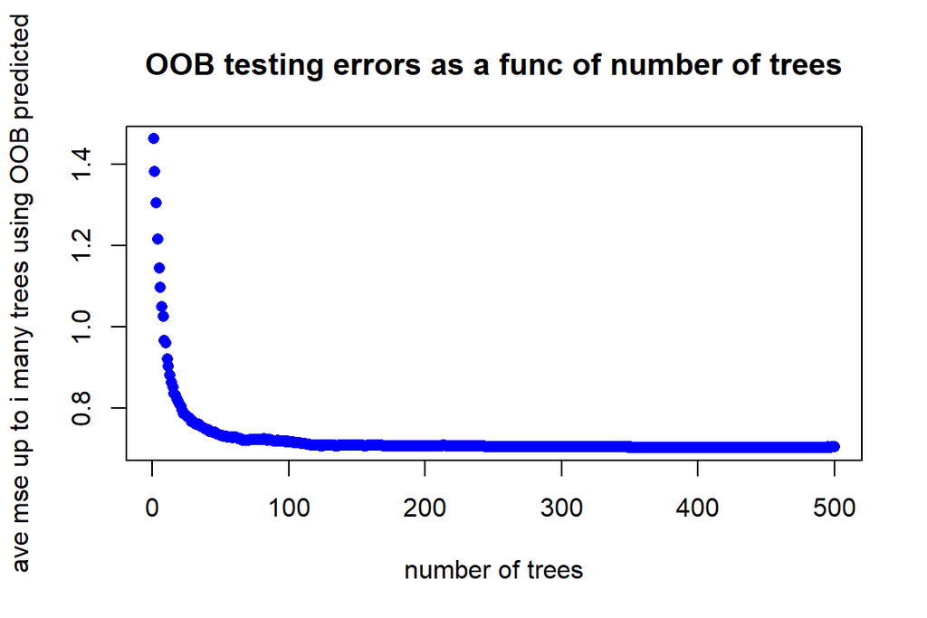

```r
plot(fit4$mse, xlab="number of trees", col="blue",
     ylab="ave mse up to i many trees using OOB predicted",
     pch=16) # We only need about 100 trees for this
title(main = "OOB testing errors as a func of number of trees")
```

```r
rf.error.p <- 1:19  # set up a vector of length 19
for (p in 1:19)  # repeat the following code inside { } 19 times
{
  fit5 <- randomForest(LogIncome2005 ~ ., data = train_data, mtry = 5, ntree = 250)
  #plot(fit5, col= p, lwd = 3)
  rf.error.p[p] <- fit5$mse[250]  # collecting oob mse based on 250 trees
}
rf.error.p   # oob mse returned: should be a vector of 19
```

```
##  [1] 0.7099712 0.7134535 0.7126615 0.7100376 0.7104083 0.7076761 0.7133138
##  [8] 0.7135399 0.7120688 0.7067218 0.7100277 0.7103641 0.7097488 0.7100167
## [15] 0.7102870 0.7041468 0.7085835 0.7088903 0.7162623
```